# rownania_rozniczkowe_2

## Rozwiązywanie równań różniczkowych zwyczajnych

### Zagadnienie brzegowe

W równaniach różniczkowych rzędu drugiego lub wyższych rzędów mogą być zadane warunki brzegowe na rozwiązanie y(t) lub jego pochodne w dwóch różnych wartościach t=a i t=b.

\begin{equation} \label{eq:rr1} \frac{d^2y}{dt^2}=f(t,y,y^{\prime}) \end{equation}

z warunkami brzegowymi

\begin{equation} \label{eq:wb1} y(a)=y_a, \;\;y(b)=y_b \end{equation}

### Metoda strzałów

polega na zamianie warunków brzegowych (\ref{eq:wb1}) na warunki początkowe

\begin{equation} \label{eq:wp1} y(a)=y_a, \;\; y^{\prime}(a)=u \end{equation}

z nieznaną wartością u, którą należy dobrać tak, aby rozwiązanie zagadnienia początkowego spełniało drugi warunek brzegowy $y(t=b)=y_b$.

#### Przykład nr 1

Rozwiązać równanie różniczkowe

\begin{equation} \label{eq:rrp1} y^{\prime\prime}+2y^{\prime}+3y^2=0 \end{equation}

z warunkami brzegowymi

\begin{equation} \label{eq:wbp1} y(0)=0, \;\;y(2)=-1 \end{equation}

Najpierw zamienimy równanie (\ref{eq:rrp1}) na układ równań pierwszego rzędu

\begin{eqnarray} \label{eq:urp1a} \frac{dy}{dt}&=&y^{\prime}\\ \label{eq:urp1b} \frac{dy^{\prime}}{dt}&=&-2y^{\prime}-3y^2 \end{eqnarray}

i utworzymy w pythonie funkcję zwracającą prawe strony równań (\ref{eq:urp1a}) i (\ref{eq:urp1b})

```python
def fur1(t,y):
    return [y[1], -2*y[1]-3*y[0]**2]
```

Rozwiążemy układ równań (\ref{eq:urp1a}) i (\ref{eq:urp1b}) z warunkami początkowymi $y(0)=0\; i \;y^{\prime}(0)=u$.

Jaką wartość $u$ wybrać aby rozwiązanie spełniało warunek brzegowy $y(2)=-1$ ?

Sprawdzimy graficznie wyniki rozwiązań układu równań (\ref{eq:urp1a}) i (\ref{eq:urp1b}) dla $u=-0.5, 0, 0.5$

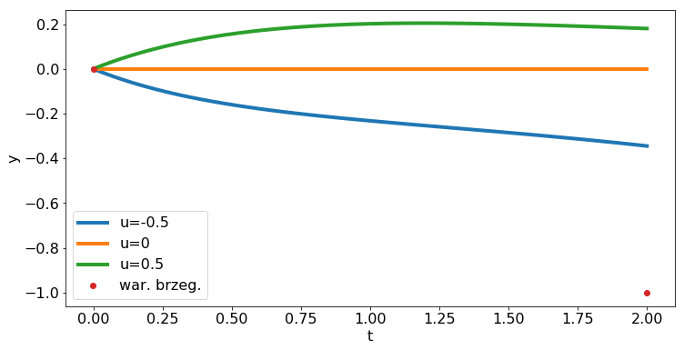

```python
import numpy as np
from scipy.integrate import solve_ivp
%matplotlib  inline
import matplotlib.pyplot as plt
plt.rcParams.update({'font.size': 16})
fig,ax1=plt.subplots(figsize=(12, 6))

utest=[-0.5,0,0.5]
y_a=0
t_k=2
y_b=-1
for u in utest:
    y0=[y_a,u]
    wu=solve_ivp(fur1,[0,t_k],y0,atol=1e-10,rtol=1e-8)
    napis='u='+str(u)
    ax1.plot(wu.t, wu.y[0],linewidth=4,label=napis)
ax1.plot([0,t_k], [y_a,y_b],'o',label='war. brzeg.')
ax1.set_xlabel('t')
ax1.set_ylabel('y')
ax1.legend()
plt.show()
```

Zamiast szukania wartości u metodą prób i błędów, możemy zadeklarować funkcję

\begin{equation} \label{eq:fun_g} g(u)=y_u(b)-y_b \end{equation}

gdzie $y_u$ jest rozwiązaniem równania (\ref{eq:rr1}) z warunkami początkowymi (\ref{eq:wp1}). Szukana wartość u jest pierwiastkiem równania $g(u)=0$, który możemy obliczyć metodami poznanymi wcześniej, np. metodą Newtona.

```python
# deklaracja g(u) dla przykładu nr1
y_a=0
t_k=2
y_b=-1
def g(u):
    y0=[y_a,u]
    woh=solve_ivp(fur1,[0,t_k],y0,atol=1e-10,rtol=1e-8)
    return woh.y[0,-1]-y_b
```

Żeby określić przybliżoną wartość pierwiastka równania

\begin{equation} \label{pierw_1} g(u)=0 \end{equation}

wykreślimy tę funkcję dla -2<u<2

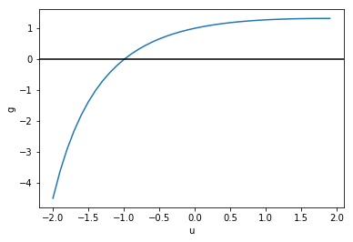

```python
vg=np.vectorize(g)
zu=np.arange(-2,2,0.1)
plt.plot(zu,vg(zu))
plt.axhline(y=0,color='k')
plt.xlabel('u')
plt.xlabel('u')
plt.ylabel('g')
plt.show()
```

Teraz znajdziemy $u_p$, precyzyjną wartość pierwiastka równania (\ref{pierw_1}), za pomocą funkcji optimize.newton(), startując z wartości początkowej $u_0=-1$.

Następnie rozwiążemy jeszcze raz układ równań (\ref{eq:urp1a}) i (\ref{eq:urp1b}) dla tej wartości $u_p$, żeby przedstawić rozwiąznie tego układu na wykresie

```
u_p=  -0.9942035631770235   g(u_p)= 0.0
```

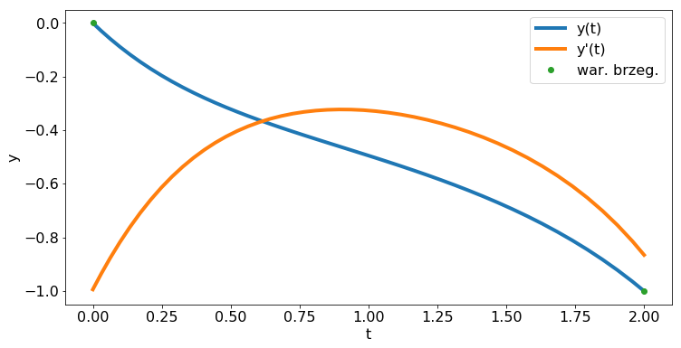

```python
from scipy import optimize
u0=-1.0
u_p=optimize.newton(g,u0,tol=1e-12,maxiter=150)
print('u_p= ',u_p,'  g(u_p)=',g(u_p))
y0=[y_a,u_p]
wms1=solve_ivp(fur1,[0,t_k],y0,atol=1e-10,rtol=1e-8)
plt.rcParams.update({'font.size': 16})
fig,ax1=plt.subplots(figsize=(12, 6))

ax1.plot(wms1.t, wms1.y[0],linewidth=4,label='y(t)')
ax1.plot(wms1.t, wms1.y[1],linewidth=4,label="y'(t)")
ax1.plot([0,t_k], [y_a,y_b],'o',label='war. brzeg.')
ax1.set_xlabel('t')
ax1.set_ylabel('y')
ax1.legend()
plt.show()
```

#### Zastosowanie metody strzałów do rozwiązania jednowywmiarowego równania Schrodingera

Przedstawimy tutaj metodę numerycznego rozwiązania równania Schrodingera

\begin{equation} \label{rSch} \frac{-\hbar^2}{2m}\frac{d^2\psi}{dx^2} +V(x)\psi(x)=E\psi(x) \end{equation}

Naszym celem jest znalezienie energii własnych $E_i$ i stanów własnych $\psi_i(x)$ dla zadanego potencjału V(x).

Zaczniemy od kwantowego oscylatora harmonicznego z

\begin{equation} \label{voh} V(x)=\frac{m\omega^2}{2}x^2 \end{equation}

Podstawienie

\begin{equation} x=\sqrt{\frac{\hbar}{m\omega}}\xi \end{equation}

sprowadza równanie (\ref{rSch}) do bezwymiarowej postaci

\begin{equation} \label{brSch} -\frac{d^2\psi}{d\xi^2} +\xi^2\psi(\xi)=2\epsilon\psi(\xi) \end{equation}

z $\epsilon$ związanym z E relacją $E=\hbar\omega\epsilon$.

Kolejny krok to zamiana równania (\ref{brSch}) na układ równań pierwszego rzędu

\begin{eqnarray} \label{eq:uroha} \frac{d\psi}{d\xi}&=&\psi^{\prime}\\ \label{eq:urohb} \frac{d\psi^{\prime}}{d\xi}&=& (\xi^2-2\epsilon)\psi \end{eqnarray}

W numerycznym rozwiązaniu przyjmiemy warunki brzegowe $\psi(\xi=-a)=\psi(\xi=a)=0$, wybierając a tak, aby $\psi(\pm a)$ było dostatecznie małe.  
Zamienimy te warunki brzegowe na warunki początkowe: $\psi(\xi=-a)=0$ i dowolną wartość $\psi^\prime$ w $\xi=-a$, np. $\psi^\prime(\xi=-a)=1$. Metodą strzałów będziemy szukać takich wartości $\epsilon$, dla których funkcja falowa $\psi(\xi)$ spełnia drugi warunek brzegowy, $\psi(\xi=a)=0$

Utworzymy w pythonie funkcję zwracającą prawe strony równań (\ref{eq:uroha}) i (\ref{eq:urohb})

```python
#oscylator harmoniczny
def oh(x,y,E):
    return [y[1], (x**2-2*E)*y[0]]
```

Teraz utworzymy funkcję, która dla zadanej wartości energii rozwiąże układ równań (\ref{eq:uroha}) i (\ref{eq:urohb}), zwracając wartość funkcji falowej w punkcie $\xi=a$.

```python
def fkon(E,a):
    y0=[0,1.0]
    woh=solve_ivp(lambda t,y:oh(t,y,E),[-a,a],y0,atol=1e-10,rtol=1e-8)
    return(woh.y[0,-1])
```

Zastosujemy metodę Riddera z scipy.optimize do znalezienia kilku pierwszych energii własnych, czyli znalezienia pierwiastków równania

\begin{equation}\label{eq:proh} fkon(E,a)=0 \end{equation}

```python
a=5.5
# wybór warunków brzegowych - znikanie funkcji falowej,
# należy starannie przetestować
# Zbyt duże a prowadzi do olbrzymich wartości y[a], np dla a=10
E1=0.1
dE=0.1
Esp=[]
for E2 in np.arange(0.2,5,dE):
    if np.sign(fkon(E1,a))!=np.sign(fkon(E2,a)):
        prE=optimize.ridder(fkon,E1,E2,args=(a,))
        print(prE)
        Esp.append(prE)

    E1=E2
```

```
0.49999999986179466
1.499999999711514
2.5000000002249196
3.500000012517074
4.500000170893462
```

Obliczone energie własne oscylatora harmonicznego są z duża dokładnością zgodne z wynikami dokładnymi

\begin{equation} \epsilon_i=i+\frac{1}{2},\;\;\;\; i=0,1,2,\ldots \end{equation}

W celu znalezienia funkcji falowych rozwiążemy jeszcze raz równania różniczkowe dla obliczonych energii własnych oscylatora. Ponieważ funkcje fallowe powinny być unormowane,

\begin{equation} \label{eq:calka} \int_{-\infty}^{\infty}{|\psi(x)|^2 dx}=1 \end{equation}

to wykorzystamy CubicSpline do interpolacji i obliczenia całki z kwadratu funkcji falowej.

```python
#normalizacja ff
from scipy.interpolate import CubicSpline
def norm_ff(xx,ff):
    ff2=ff**2
    cs = CubicSpline(xx, ff2)
    nrm=1/np.sqrt(cs.integrate(xx[0], xx[-1]))
    return ff*nrm
```

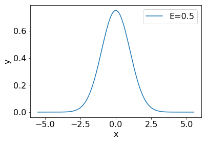

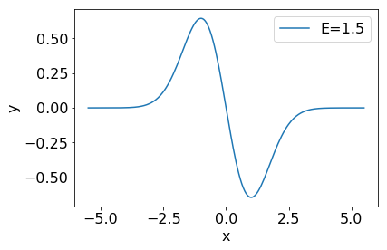

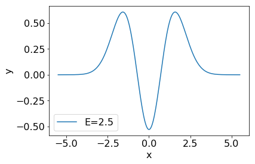

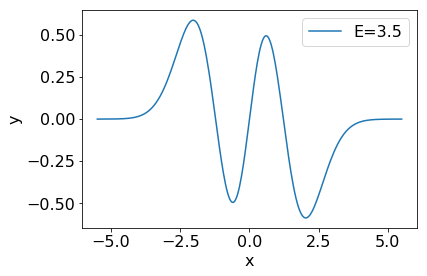

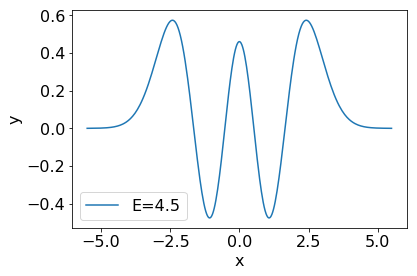

```python
y0=[0,1.0]
for Etym in Esp:
    woh=solve_ivp(lambda t,y:oh(t,y,Etym),[-a,a],y0,atol=1e-10,rtol=1e-8)
    tlab='E='+str(round(Etym,3))
    plt.plot(woh.t, norm_ff(woh.t,woh.y[0]),label=tlab)
    plt.xlabel('x')
    plt.ylabel('y')
    plt.legend()
    plt.show()
```

#### Oscylator anharomiczny

Dodając do potencjału harmonicznego (\ref{voh}) wyraz proporcjonalny do $x^4$ otrzymamy bezwymiarową postać równania Schrodingera

\begin{equation} \label{ahbrSch} -\frac{d^2\psi}{d\xi^2} +(\xi^2+2\lambda\xi^4\psi(\xi)=2\epsilon\psi(\xi) \end{equation}

oraz równoważny układ równań różniczkowych pierwszego rzędu

\begin{eqnarray} \label{eq:uroaha} \frac{d\psi}{d\xi}&=&\psi^{\prime}\\ \label{eq:uroahb} \frac{d\psi^{\prime}}{d\xi}&=& (\xi^2+2\lambda\xi^4-2\epsilon)\psi \end{eqnarray}

```python
#oscylator anharmoniczny
def oah(x,y,E,lam):
    return [y[1], (x**2+2*lam*x**4-2*E)*y[0]]

def fkonah(E,lam,a):
    y0=[0,1.0]
    woah=solve_ivp(lambda t,y:oah(t,y,E,lam),[-a,a],y0,atol=1e-10,rtol=1e-8)
    return(woah.y[0,-1])
```

```python
lam=0.2
ah=4.6
# w tym przypadku wybieramy a nieco mniejsze niż dla oscylatora harmonicznego
# ponieważ obecność wyrazu lam*x**4 powoduje szybszy zanik funkcji falowej z odlegością od x=0
E1=0.1
dE=0.1
Eah=[]
for E2 in np.arange(0.2,7,dE):
    if np.sign(fkonah(E1,lam,ah))!=np.sign(fkonah(E2,lam,ah)):
        prE=optimize.ridder(fkonah,E1,E2,args=(lam,ah))
        print(prE)
        Eah.append(prE)

    E1=E2
```

```
0.6024051635291046
1.9505435251394179
3.536299362389004
5.291268541308415
```

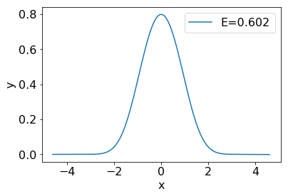

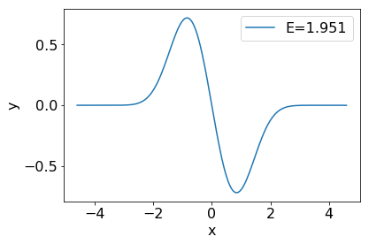

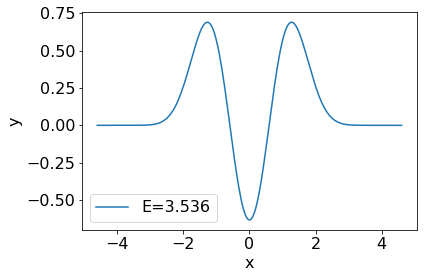

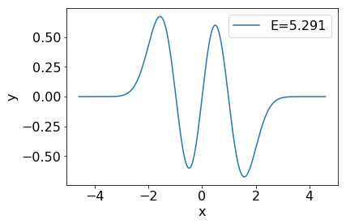

```python
# Widzimy że różnice między kolejnymi energiami, E_{i+1}-E_i, rosną rosną
# z numerem poziomu i.

# Sprawdzimy teraz jak wyraz anharmoniczny zmienia funkcje falowe
y0=[0,1.0]
for Etym in Eah:
    woah=solve_ivp(lambda t,y:oah(t,y,Etym,lam),[-ah,ah],y0,atol=1e-10,rtol=1e-8)
    tlab='E='+str(round(Etym,3))
    plt.plot(woah.t, norm_ff(woah.t,woah.y[0]),label=tlab)
    plt.xlabel('x')
    plt.ylabel('y')
    plt.legend()
    plt.show()
```

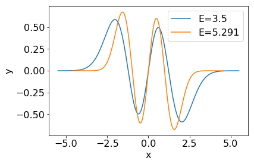

```python
#porównanie ff
i=3
woh=solve_ivp(lambda t,y:oh(t,y,Esp[i]),[-a,a],y0,atol=1e-10,rtol=1e-8)
tlab='E='+str(round(Esp[i],3))
plt.plot(woh.t, norm_ff(woh.t,woh.y[0]),label=tlab)
woah=solve_ivp(lambda t,y:oah(t,y,Eah[i],lam),[-ah,ah],y0,atol=1e-10,rtol=1e-8)
tlab='E='+str(round(Eah[i],3))
plt.rcParams.update({'font.size': 16})
plt.plot(woah.t, norm_ff(woah.t,woah.y[0]),label=tlab)
plt.xlabel('x')
plt.ylabel('y')
plt.legend()
plt.show()
```

Funkcje falowe (ff) oscylatora anharmonicznego są bardziej zlokalizowane niż ff oscylatora harmonicznego

#### Skończona studnia potencjału

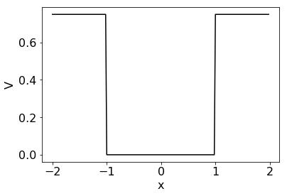

```python
#Rysunek studni potencjału o szerokości w=2 nm i głębokości V_0=0.7 eV

w=2
xq=w/2
V0=0.75

def Vqw(x):
    if x<=-xq:
        return V0
    elif x<xq:
        return 0
    else:
        return V0

vecV=np.vectorize(Vqw)
xx=np.arange(-w,w,w/100)
plt.plot(xx,vecV(xx),color='k')
plt.xlabel('x')
plt.ylabel('V')
plt.show()
```

Równanie Schrodingera dla elektronu w prostokątnej studni potencjału

\begin{equation} \label{qwSch} \frac{-\hbar^2}{2m}\frac{d^2\psi}{dx^2} +V(x)\psi(x)=E\psi(x) \end{equation}

Wyrażając energię w eV i położenie w nanometrach, układ równań pierwszego rzędu przyjmie postać

\begin{eqnarray} \label{eq:urqwa} \frac{d\psi}{dx}&=&\psi^{\prime}\\ \label{eq:urqwb} \frac{d\psi^{\prime}}{dx}&=& c(V(x)-E)\psi \end{eqnarray}

gdzie $$c=\frac{2* 9.109383* 10^{-31} *1.602176* 10^{-19} * 10^{-18}}{(1.054571)^2* 10^{-68}}$$

```python
# funkcja zwracająca prawe strony 2 równań różniczkowych
c=2*9.109383*1.602176/1.054571**2
def qw(t,y,E):
    return [y[1], c*(Vqw(t)-E)*y[0]]
# funkcja rozwiązująca w\2 równania różniczkowe i zwracająca w x=a
def fqw(E,a):
    y0=[0,1.0]
    wqw=solve_ivp(lambda t,y:qw(t,y,E),[-a,a],y0,atol=1e-12,rtol=1e-9)
    return(wqw.y[0,-1])
```

```python
# obliczenie energii własnych stanów związanych
a=3.5*xq
E1=0.001
dE=V0/10
Eqw=[]
for E2 in np.arange(dE,V0,dE):
    if np.sign(fqw(E1,a))!=np.sign(fqw(E2,a)):
        prE=optimize.ridder(fqw,E1,E2,args=(a,),xtol=1e-12,rtol=1e-9)
        print(prE)
        Eqw.append(prE)

    E1=E2
```

```
0.06227592570299728
0.24460028464323683
0.5268337705867527
```

Porównajmy te wyniki obliczone metodą strzałów z wynikami otrzymanymi z rozwiązania równań nieliniowych dla studni potencjału o tych samych parametrach - kilka wykładów wcześniej

E= 0.06227597891064637

E= 0.24460049058551703

E= 0.5268331438882831

Obserwujemy dużą zgodność między tymi dwoma podejściami.

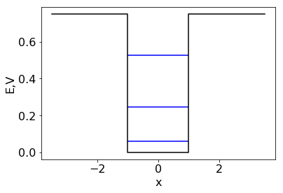

```python
# Wykres energii własnych

for etym in Eqw:
    lab = "E=" + str(etym)
    plt.hlines(etym,-xq,xq,colors='b')

xtd=[-a,-xq,-xq,xq,xq,a]
ytd=[V0,V0,0,0,V0,V0]

plt.plot(xtd,ytd,color='k')
plt.xlabel('x')
plt.ylabel('E,V')
plt.show()
```

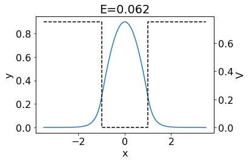

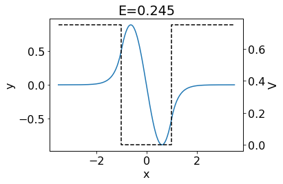

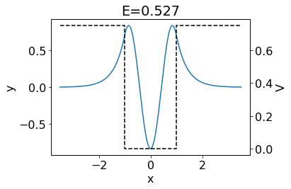

```python
# wykreślenie unormowanych funkcji falowych
y0=[0,1.0]
for Etym in Eqw:
    wqw=solve_ivp(lambda t,y:qw(t,y,Etym),[-a,a],y0,atol=1e-12,rtol=1e-9)
    tlab='E='+str(round(Etym,3))
    fig,ax1=plt.subplots()
    ax1.set_title(tlab)
    ax1.set_xlabel('x')
    ax1.set_ylabel('y')
    ax2=ax1.twinx()
    ax2.set_ylabel('V')
    ax2.plot(xtd,ytd,color='k',linestyle='--')
    ax1.plot(wqw.t, norm_ff(wqw.t,wqw.y[0]) )
    fig.tight_layout()
    plt.show()
```

### Metoda różnic skończonych

Równanie różniczkowe drugiego (lub wyższego) rzędu

\begin{equation} \label{eq:mrs1} \frac{d^2y}{dx^2}=f(x,y,y^{\prime}) \end{equation}

z zadanymi warunkami brzegowymi

\begin{equation} \label{eq:mrs2} y(a)=\alpha, \;\;y(b)=\beta \end{equation}

możemy rozwiązać wprowadzając sieć dyskretnych punktów

\begin{equation} \label{eq:mrs3} x_i = a +ih;\;\;h=\frac{b-a}{n}, \;\; i=0,1,\ldots,n \end{equation}

oraz przybliżając pochodne róznicami skończonymi

\begin{equation} \label{eq:mrs4} y_i^{\prime\prime}=\frac{y_{i-1}-2y_{i}+y_{i+1} }{ h^2} \end{equation}\begin{equation} \label{eq:mrs5} y_i^{\prime}=\frac{y_{i+1}-y_{i-1} }{2h} \end{equation}

gdzie $y_i\equiv y(x_i)$.

Uwzględniając warunki brzegowe $y_0=\alpha, \;\;y_n=\beta$, obliczymy $y_1,\ldots,y_{n-1}$ rozwiązując układ $n-1$ równań

\begin{equation} \label{eq:mrs6} y_{i-1}-2y_{i}+y_{i+1}=h^2f_i,\;\;\; i=1,2,\dots,n-1 \end{equation}

gdzie $f_i\equiv f(x_i,y_i,y_i^{\prime})$.

Jeśli $f(x,y,y^{\prime})$ jest nieliniową funkcją $y$ i $y^{\prime}$ to problem jest trudniejszy, ponieważ rozwiązanie (\ref{eq:mrs6}) wymaga stosowania metody Newtona-Raphsona do znalezienia pierwiastków tego układu równań. Dla funkcji liniowych rozwiązania możemy dostać metodu LU.

Przykład.

Rozwiążemy równanie (\ref{eq:mrs1}) z funkcją

\begin{equation} \label{eq:mrs7} f(x,y,y^{\prime})=-y-2y^{\prime} \end{equation}

i warunkami brzegowymi $y(0)=0, \;\;y(1)=1$.

Wybierzemy n+1 punktów $x_i=ih,\;\;h=1/n,\;\;i=0,1,\ldots,n$

Dyskretne wartości $f_i$ obliczymy z (\ref{eq:mrs7}) i (\ref{eq:mrs5})

\begin{equation} \label{eq:wfi} f_i=-y_i-2y^{\prime}_i=-y_i-\frac{y_{i+1}-y_{i-1} }{h} \end{equation}

Podstawiając (\ref{eq:wfi}) do (\ref{eq:mrs6}) otrzymamy n-1 równań liniowych na $y_i$

\begin{equation} \label{eq:mrs8} (1-h)y_{i-1}+(h^2-2)y_{i}+(1+h)y_{i+1}=0,\;\;\; i=1,2,\dots,n-1 \end{equation}

Uwzględniając warunki brzegowe $y_0=0$ i $y_n=1$ zapiszemy końcową postać układu równań liniowych

$$\mathbb{A}\mathbb{y}=\mathbb{u}$$

z

$\mathbb{y}=\left(y_1,y_2,\ldots,y_{n-2},y_{n-1}\right)^T$,

$\mathbb{u}=\left(0,0,\ldots,0,-h-1\right)^T$

i trójdiagonalną macierzą

\begin{equation} \mathbb{A}=\left(\begin{matrix} d & e_2 & 0 & 0 &0 & \cdots & 0\\ e_1 & d & e_2 & 0 &0 & \cdots & 0\\ 0 & e_1 & d & e_2 &0 & \cdots & 0\\ & & \ddots& \ddots& \ddots & & \\ 0 & \cdots &0 & e_1 & d & e_2& 0\\ 0 & \cdots & 0 &0 & e_1 & d & e_2\\ 0 & \cdots & 0 &0 & 0 & e_1 & d \end{matrix}\right) \end{equation}

gdzie $$ d=h^2-2,\;\;\;e_1=1-h,\;\;e_2=1+h $$

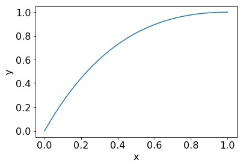

```python
import numpy as np
# wykorzystamy macierze i układy rzadkie
from scipy.sparse import diags
n=1000000  #można obliczyć dla n=1000000 !!!
h=1.0/n
#diagonala
d=(h**2-2)*np.ones(n-1)
# pod diagonalą
e1=(1-h)*np.ones(n-2)
# nad diagonalą
e2=(1+h)*np.ones(n-2)
#lista niezerowych elementów macierzy rzadkiej
data=[d.tolist(),e2.tolist(),e1.tolist()]
positions=[0,1,-1]
A=diags(data,positions,(n-1,n-1))
uu=np.zeros(n-1)
uu[n-2]=-h-1
# csr - compressed sparse  row format
A =A.tocsr()
# rozwiązanie układu równań liniowych
from scipy.sparse.linalg  import spsolve
y = spsolve(A, uu)

x=np.arange(h,1,h)
plt.plot(x, y)
plt.xlabel('x')
plt.ylabel('y')
plt.show()
```

```python
# rozwiązanie metodą strzałow w celu porównania dwóch podejść
def fur2(t,y):
    return [y[1], -2*y[1]-y[0]]
from scipy.integrate import solve_ivp
y_a=0
t_k=1
y_b=1
def fms2(u):
    y0=[y_a,u]
    woh2=solve_ivp(fur2,[0,t_k],y0,atol=1e-10,rtol=1e-8)
    return woh2.y[0,-1]-y_b
```

```python
for u in np.arange(2,5,0.5):
    print(u,'  ',fms2(u))
```

```
2.0    -0.26424111820924845
2.5    -0.08030139775656175
3.0    0.10363832269619944
3.5    0.2875780431490993
4.0    0.4715177636030219
4.5    0.65545748402509
```

```
u_p=  2.7182818304793304   fms2(u_p)= 2.220446049250313e-16
```

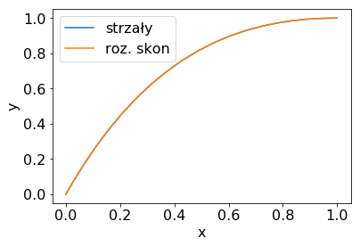

```python
from scipy import optimize
import matplotlib.pyplot as plt
u0=3
u_p=optimize.newton(fms2,u0,tol=1e-12,maxiter=150)
print('u_p= ',u_p,'  fms2(u_p)=',fms2(u_p))
y0=[y_a,u_p]
wms2=solve_ivp(fur2,[0,t_k],y0,atol=1e-10,rtol=1e-8)
plt.plot(wms2.t, wms2.y[0],label='strzały')

plt.plot(x, y,label='roz. skon')
plt.xlabel('x')
plt.ylabel('y')
plt.legend()
plt.show()
```